# Reef Fish Abundance Across Time

## Introduction to my Data and Analyses

- The raw data compares the presence and absence of 470 coral reef fish species in 5 dive sites in Papua New Guinea in the 21st century
- There is also presence/absence data for a historical museum collection from one site (Bootless Bay, circa 1881).
- This analysis examines changes in species richness in Bootless Bay over time, and whether fishing pressure correlates to any changes seen.

## Study Sites

[figure not shown]

A map of the five dive sites sampled in this study.

Image source: http://journals.plos.org/plosone/article?id=10.1371/journal.pone.0140682

## Modifying Raw Data

- I used the filter commmand to filter out rows where species were not present at either location.
- I selected columns with the following data: Genus, species, presence/absence in Bootless Bay (21st century), presence/absence in museum collection (1881-1889), and fishing pressure (fished/not fished).
- I used gather() to establish a location column (categorical, Bootless vs Museum), and catch_code column (0 for absence, 1 for presence) to better organize the data.

`` reef_fish_bootless <- select(reef_fish, Genus, species, Bootless, Museum.Bootless, Fished) %>% filter(Bootless > 0 | Museum.Bootless > 0) %>% filter(Bootless < 50) %>% gather(`Museum.Bootless`, `Bootless`, key = "location", value = "catch_code") ``

## Separating by Fishing Pressure

- I made separate data frames for species that were fished and not fished. This would later help me see if fishing pressure had anything to do with what trends might appear.

`reef_fish_bootless_fished <- filter(reef_fish_bootless, Fished == "fished" | Fished == "Fished")`

`reef_fish_bootless_notfished <- filter(reef_fish_bootless, Fished == "not fished")`

## Making Useful Tables

- I grouped all the reef fish by genus and location, then summed the species seen per genus at each location in the total_catch column.

`reef_fish_bootless_sp <- group_by(reef_fish_bootless, Genus, location) %>% summarize(total_catch = sum(catch_code))`

## More Useful Tables

- I repeated this process for the data frames organized by fishing pressure.

`bootless_fished_sp <- group_by(reef_fish_bootless_fished, Genus, location) %>% summarise(total_catch = sum(catch_code))`

`bootless_notfished_sp <- group_by(reef_fish_bootless_notfished, Genus, location) %>% summarise(total_catch = sum(catch_code))`

## Graphing Data

- I used ggplot2 to plot a histogram with the species seen per genus on the x-axis and frequency of that count on the y-axis.
- Colored bars differentiate the locations: counts from the museum collection are in teal, and modern counts from Bootless Bay arer in red.

`ggplot(reef_fish_bootless_sp) +`

`geom_histogram(aes(x = total_catch, fill = location), position = "dodge") +`

`labs(x = "Species per Genus Present by Location", y = "Frequency") +`

`ggtitle("Species Richness in Bootless Bay Over Time")`

## Graph: Species Richness in Bootless Bay Over Time

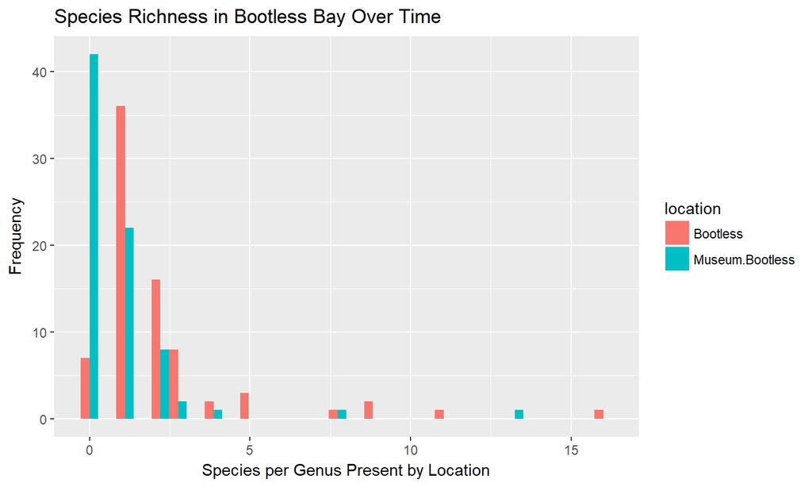

## Graph: Species Under Fishing Pressure

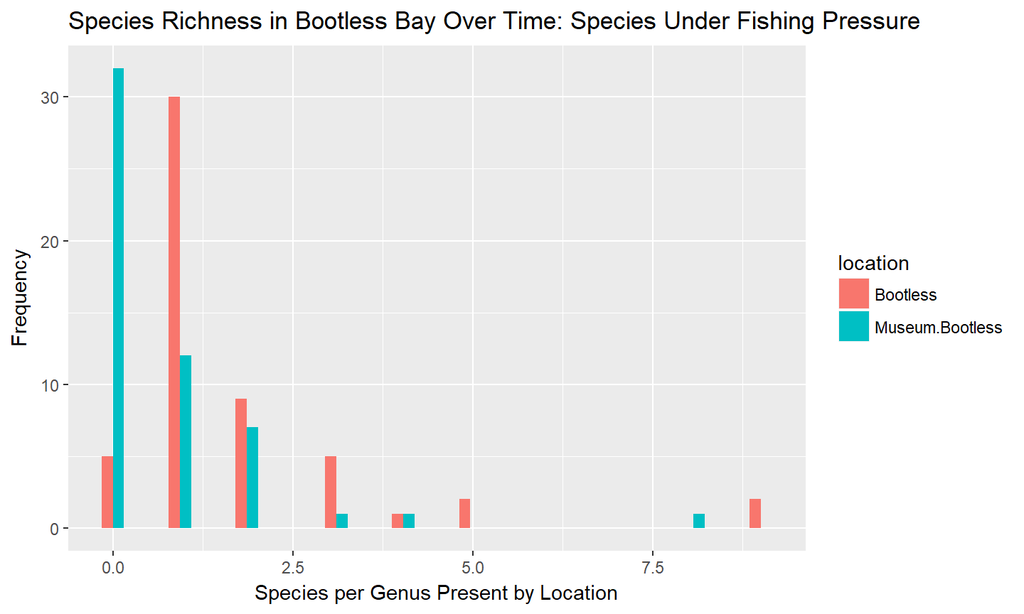

## Graph: Species Free from Fishing Pressure

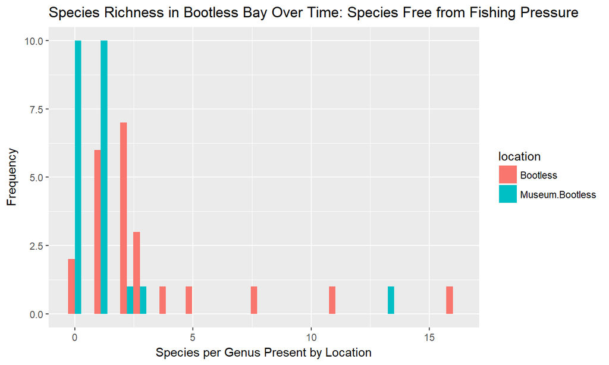

## What's Behind the Trends?

- These graphs show that there is in fact slightly higher species richness in modern studies of Bootless Bay, indicated by slightly farther right bin distribution in modern counts.
- This could be the result of indroduction of non-native species via aquarium trade or ballast water.
- It’s also possible that the museum collection does not accurately represent the full diversity of species in Bootles Bay in 1881.